# Little Women text wrangling and analysis

Grace Kumaishi

2/17/2021

```r
# Read in the data
little_women_text <- pdf_text(here("little_women.pdf"))

# Wrangling!
little_women_tidy <- data.frame(little_women_text) %>%
  mutate(text_full = str_split(little_women_text, pattern = "\\n")) %>%
  unnest(text_full) %>%
  mutate(text_full = str_trim(text_full))

little_women_df <- little_women_tidy %>%
  slice(-(1:101)) %>%
  mutate(chapter = case_when(
    str_detect(text_full, pattern = "CHAPTER") ~text_full,
    TRUE ~ NA_character_
  )) %>%
  fill(chapter) %>%
  mutate(text_full = str_squish(text_full)) %>% # Get rid of excess inside space in text_full
  mutate(text_full = str_trim(text_full)) %>% # Get rid of excess outside space
  mutate(chapter = str_squish(chapter)) %>%
  mutate(chapter = str_remove_all(as.character(chapter), "\\.")) %>% # remove "." after roman numerals
  separate(col = chapter, into = c("ch", "no"), sep = " ") %>%
  mutate(chapter = as.numeric(as.roman(no))) %>% # Not sure how to fix this??
  replace_na(list(chapter = 18)) # Replace NAs with 18

# Get word counts by chapter
little_women_tokens <- little_women_df %>%
  unnest_tokens(word, text_full) %>%
  dplyr::select(-little_women_text)

little_women_wordcount <- little_women_tokens %>%
  count(chapter, word)

# Remove all stop words and other unwanted names/words
little_women_nonstop_words <- little_women_tokens %>%
  anti_join(stop_words) %>%
  filter(word != "jo",
         word != "jo's",
         word != "beth",
         word != "amy",
         word != "meg",
         word != "laurie",
         word != "laurence",
         word != "11",
         word != "n't",
         word != "ve",
         word != "ing")

nonstop_counts <- little_women_nonstop_words %>%
  count(chapter, word)
```

### 1) Top 5 words in *Little Women* part 1

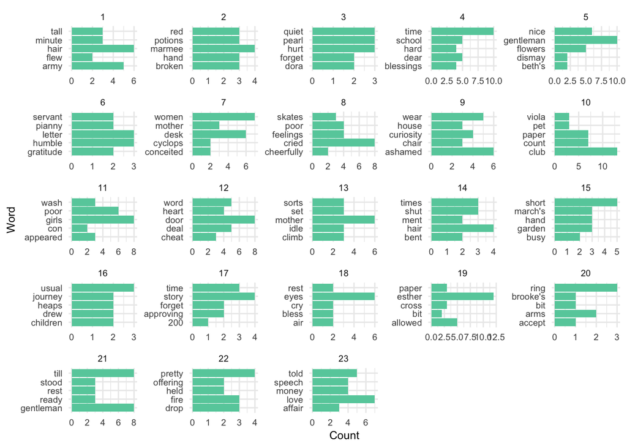

```r
# Find top 5 words for part 1
top_5_words <- nonstop_counts %>%
  filter(chapter == 1:23) %>% # filter for first 15 chapters
  group_by(chapter) %>%
  arrange(-n) %>%
  slice(1:5)

# Visualize
ggplot(data = top_5_words, aes(x = word, y = n)) +
  geom_col(fill = "aquamarine3") +
  facet_wrap(~chapter, scales = "free") +
  coord_flip() +
  theme_minimal() +
  theme(text = element_text(size = 9),
        plot.title = element_text(hjust = .5, size = 14)) +
  labs(x = "Word",
      y = "Count")
```

**Figure 1:** Column graphs faceted by chapter to display top 5 most commonly used words in Louisa May Alcott’s *Little Women* part 1 (chapters 1 - 23). Stop words such as “the”, “is”, and “and” were removed in addition to character names.

### 2) Top 50 words in *Little Women* chapter 5: “Being Neighborly”

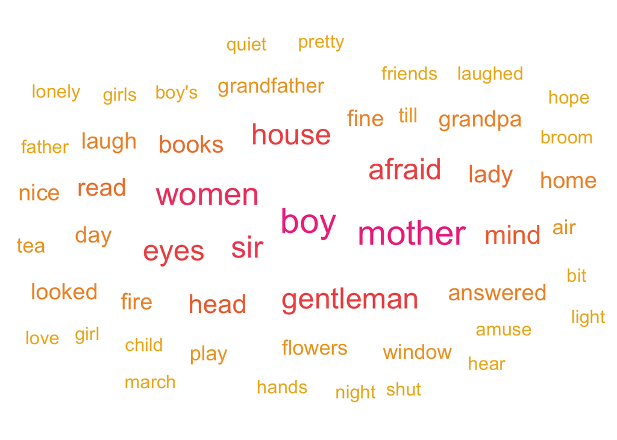

```r
# Select top 50 words
ch5_top50 <- nonstop_counts %>%
  filter(chapter == 5) %>%
  arrange(-n) %>%
  slice(1:50)

# Create wordcloud
ch5_cloud <- ggplot(data = ch5_top50, aes(label = word)) +
  geom_text_wordcloud(aes(color = n, size = n), shape = "circle") +
  scale_size_area(max_size = 10) +
  scale_color_gradientn(colors = c("goldenrod2", "tomato2", "violetred2")) +
  theme_minimal()

ch5_cloud
```

**Figure 2:** Wordcloud displaying the top 50 words used in *Little Women* chapter 5: “Being Neighborly”. Similar to figure 1, stop words and main character names were removed to provide a more interesting assortment of words.

### 3) Sentiment analysis of *Little Women* parts 1 & 2 using the AFINN lexicon

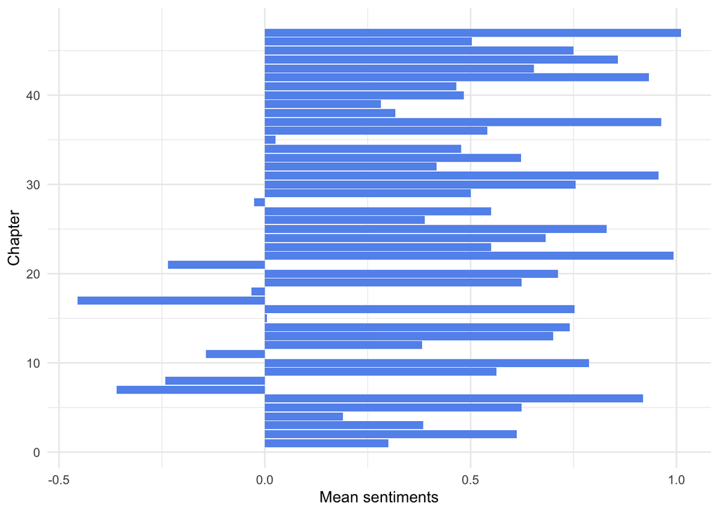

```r
# Sentiment analysis using afinn lexicon
afinn_pos <- get_sentiments("afinn") %>% # check out all words that are scored as "positive" or above 2
  filter(value > 2)

little_women_afinn <- little_women_nonstop_words %>%
  inner_join(get_sentiments("afinn"))

afinn_counts <- little_women_afinn %>%
  count(chapter, value)

afinn_means <- little_women_afinn %>%
  group_by(chapter) %>%
  summarize(mean_afinn = mean(value))

ggplot(data = afinn_means,
       aes(x = chapter, y = mean_afinn)) +
  geom_col(fill = "cornflowerblue") +
  coord_flip() +
  theme_minimal() +
  labs(y = "Mean sentiments",
       x = "Chapter")
```

**Figure 3:** Column graph showcasing the average sentiments of *Little Women* parts 1 & 2 (chapters 1 - 47) using the AFINN lexicon. Mean sentiment values less than zero indicate that on average, the words used in a particular chapter had more negative connotations than those that show mean sentiments greater than zero.

```r
# Sentiment analysis using NRC lexicon
#little_women_nrc <- little_women_nonstop_words %>%
  #inner_join(get_sentiments("nrc"))

#little_women_nrc_counts <- little_women_nrc %>%
  #count(chapter, sentiment)

#ggplot(data = little_women_nrc_counts, aes(x = sentiment, y = n)) +
  #geom_col() +
  #facet_wrap(~chapter) +
  #coord_flip()
```

### Citation:

[Alcott, Louisa May, 1832-1888. Little Women. Melbourne ; London ; Baltimore :Penguin Books, 1953](https://archive.org/details/littlewomenormeg00alcoiala/page/216/mode/2up)